# Exectutive Summary of DataSet

##### Key Insight

Around 2016–2019, the number of sales begins to rise modestly, reflecting gradual growth in the Texas housing market.

##### Key Insight

March and April have the highest number of sales, indicating a strong spring market when buyer activity peaks.

January and February show moderate activity, suggesting early-year momentum.

Sales drop sharply in late spring and summer (May → September), which may reflect:

- Reduced inventory
- Seasonal buyer slowdowns
- Market conditions or dataset characteristics

Sales rise again in November and December, suggesting end-of-year buying activity—possibly due to relocations, tax reasons, or seasonal promotions.

##### Key Insight

The Texas real estate market in this dataset shows a strong spring boom, a summer slowdown, and a winter rebound. Understanding these cycles is valuable for forecasting, pricing strategies, and inventory planning.

#### BoxPlot

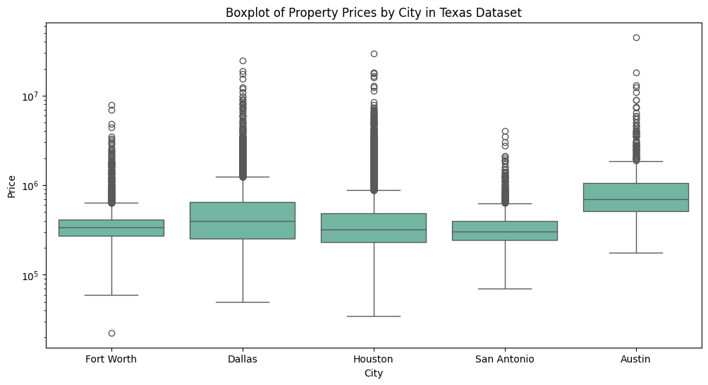

```python
#Lets visualize each city together
plt.figure(figsize=(12,6))
sns.boxplot(x='city', y='price', data=df_tx)
plt.title('Boxplot of Property Prices by City in Texas Dataset')
plt.xlabel('City')
plt.ylabel('Price')
sns.set_palette("Set2")
plt.yscale('log')
plt.show()
```

## Predictive Modeling

After completing the exploratory analysis and preparing the dataset, a linear regression model was implemented to predict home prices using several key property characteristics. The goal of this model is to quantify how features such as size, number of bedrooms, number of bathrooms, and price per square foot relate to overall home value.

Because real estate prices are highly skewed with extreme outliers, the model was trained using log-transformed prices. This transformation compresses large values, reduces the impact of extreme price points, and allows the linear model to better capture proportional changes instead of absolute jumps. Once predictions are made, the model outputs are converted back to dollar values for interpretation.

Model Features Included

The linear model uses the following predictors:

- House Size (sqft) – Larger homes generally sell for higher prices.
- Number of Bedrooms – Captures the functional capacity of the home.
- Number of Bathrooms – Often strongly correlated with market value.
- Price per Square Foot – A normalized measure of value relative to size.

Each of these features contributes uniquely to the final price prediction, and the linear regression model assigns a coefficient to each one, representing its estimated influence on the log(price).

How the Model Works

Linear regression attempts to draw a straight line (or hyperplane, with multiple features) that best fits the relationship between the selected features and the target variable. In simple terms:

- It tries to minimize the error between actual and predicted values.
- It assumes a linear relationship between features and log(price).
- It produces predictions by applying learned coefficients to each input feature.

While linear models are simple and interpretable, they cannot capture complex nonlinear effects or interactions unless those features are explicitly engineered.

Why Use Linear Regression Here?

- It is transparent — easy to interpret and explain.
- It establishes a baseline model for understanding pricing dynamics.
- It helps identify which features carry the strongest linear influence.
- It performs well when combined with log transformations on skewed economic data.

This model provides a solid starting point for understanding real estate pricing behavior in Texas. The following section evaluates how well the model performs and highlights key insights gained from comparing predicted and actual home prices.

```
RMSE (price): $587,865
MAE  (price): $88,096
R²   (on price): -1.490
```

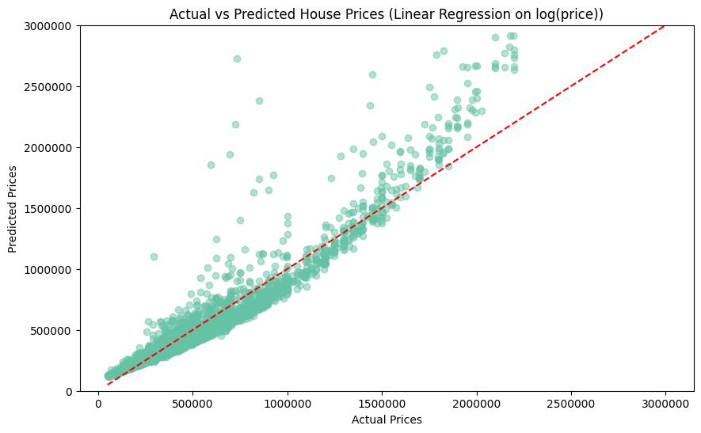

```python
# Finally, lets see if we can use a linear regression model to predict price based on house size, beds, baths, and price per sqft
from sklearn.model_selection import train_test_split
from sklearn.linear_model import LinearRegression
from sklearn.metrics import mean_squared_error, r2_score

# Define features and target variable
features = ['house_size', 'bed', 'bath', 'price_per_sqft']
df_model = df_tx.copy()

# Remove outliers for better model performance (Range Between 50,000 and 3,000,000)
df_model = df_model[(df_model['price'] >= 50000) & (df_model['price'] <= 3000000)]
df_model['log_price'] = np.log(df_model['price'])

X = df_model[features]
y = df_model['log_price']

# Train-test split
X_train, X_test, y_train, y_test = train_test_split(X, y, test_size=0.2, random_state=42)

# Fit linear regression model on log(price)
model = LinearRegression()
model.fit(X_train, y_train)

# Predictions (log scale) and convert back to price
y_pred_log = model.predict(X_test)
y_test_price = np.exp(y_test)
y_pred_price = np.exp(y_pred_log)

# Metrics on actual prices
mse = mean_squared_error(y_test_price, y_pred_price)
rmse = np.sqrt(mse)
mae = np.mean(np.abs(y_test_price - y_pred_price))
r2 = r2_score(y_test_price, y_pred_price)

print(f"RMSE (price): ${rmse:,.0f}")
print(f"MAE  (price): ${mae:,.0f}")
print(f"R²   (on price): {r2:.3f}")

# Plot the actual vs predicted prices
plt.figure(figsize=(10, 6))
plt.scatter(y_test_price, y_pred_price, alpha=0.5)

plt.plot(
    [y_test_price.min(), y_test_price.max()],
    [y_test_price.min(), y_test_price.max()],
    'r--'
)
plt.ylim(0, 3_000_000)

plt.title('Actual vs Predicted House Prices (Linear Regression on log(price))')
plt.xlabel('Actual Prices')
plt.ylabel('Predicted Prices')
plt.ticklabel_format(style='plain', axis='both')

plt.show()
```

This visualization compares the actual home sale prices in Texas with the prices predicted by a linear regression model trained on:

- House size
- Number of bedrooms
- Number of bathrooms
- Price per square foot

Because housing prices are heavily right-skewed, the model is trained using a log transformation of price, which reduces the influence of extremely high-priced properties and produces a more stable relationship between features and the target variable.

The predictions are then converted back to normal dollar values for interpretability.

### What the Graph Shows

- Each point represents a single home.
- The x-axis shows the actual sale price.
- The y-axis shows the model’s predicted price.
- The red dashed line represents perfect predictions — points falling exactly on this line would be predicted with zero error.

### Interpretation

Higher-priced homes show greater spread, which is expected because:

- luxury properties have more variation,
- linear regression isn’t ideal for modeling nonlinear price jumps,
- and log transformation compresses the upper range.

### Model Performance

- Using RMSE, MAE, and R² on the converted price values:
- RMSE reflects the average magnitude of price prediction errors.
- MAE gives the average absolute deviation between predicted and actual prices.
- R² measures how much of the variation in price is explained by the model.

# Final Insights

# Source

This project uses the USA Real Estate Dataset published on Kaggle by Ahmed Shahriar Sakib. The dataset was originally collected from Realtor.com, one of the largest real estate listing platforms in the United States.

Dataset link: https://www.kaggle.com/datasets/ahmedshahriarsakib/usa-real-estate-dataset

According to the author:

Personally identifying address details were anonymized for privacy.

acre_lot describes total land area.

house_size refers to building square footage.

The dataset is intended for educational and analytical purposes.